# Data Wrangling

# R 語言與資料科學導論作業 (W5)

語言所 博3 D04142001 司馬智

## Data Analysis (95%)

### 請使用R的內建資料`esoph`當作練習用的資料。

#### 一、請先瞭解一下這個資料的內容（`help(esoph)`）。 (15%)

- 請列出這筆資料的簡單描述統計。如果該筆變項是類別變項，請描述其次數分配；若該筆變項是連續變項，請至少列其中數和平均數。 (10%)
- 請找出這個資料集共有幾列資料。 (5%)

```r
# 瞭解一下資料的內容
help(esoph)
head(esoph)
```

```
##   agegp     alcgp    tobgp ncases ncontrols
## 1 25-34 0-39g/day 0-9g/day      0        40
## 2 25-34 0-39g/day    10-19      0        10
## 3 25-34 0-39g/day    20-29      0         6
## 4 25-34 0-39g/day      30+      0         5
## 5 25-34     40-79 0-9g/day      0        27
## 6 25-34     40-79    10-19      0         7
```

```r
#View(esoph)
```

> The dataset ‘esoph’ is called “Smoking, Alcohol and (O)esophageal Cancer”, written by Thomas Lumley. There are 5 variables: the Age group (“agegp”), the Alcohol consumption (“alcgp”), Tobacco consumption (“tobgp”), Number of cases (“ncases”), and Number of controls (“ncontrols”). （我是這樣瞭解的。）

> From these, Age group, Alcohol consumption and Tobacco consumption are ordinal variables, meaning that they have continuous ranges as their variables.

> For the variable Age group they are:
- 25-34 years
- 35-44 years
- 45-54 years
- 55-64 years
- 65-74 years
- 75+ years

> For the variable Alcohol consumption they are:
- 0-39 gm/day
- 40-79 gm/day
- 80-119 gm/day
- 120+ gm/day

> For the variable Tobacco consumption they are:
- 0-9 gm/day
- 10-19 gm/day
- 20-29 gm/day
- 30+ gm/day

> The variables Number of cases and Number of controls are doubles (so numbers) and this allows us to compute their median and mean.

```r
library(tidyverse)
esoph %>%
  select(ncases, ncontrols) %>%
  summarise(median(ncases), mean(ncases),
            median(ncontrols), mean(ncontrols))
```

```
##   median(ncases) mean(ncases) median(ncontrols) mean(ncontrols)
## 1              1     2.272727                 6        11.07955
```

> There are on average (mean) 2.272727 cases, but the median is 1.

> There are on average (mean) 11.07955 controls, but the median is 6.

```r
dim(esoph)
```

```
## [1] 88  5
```

> There are 88 rows (列) and 5 columns (行) of 資料.

#### 二、資料作圖 (20%)

- 請對此資料集做一張圖，任何圖（散佈圖、直方圖、或課堂上看到的散佈矩陣圖）都可以。

I chose ‘boxplot’ because it was very revealing.

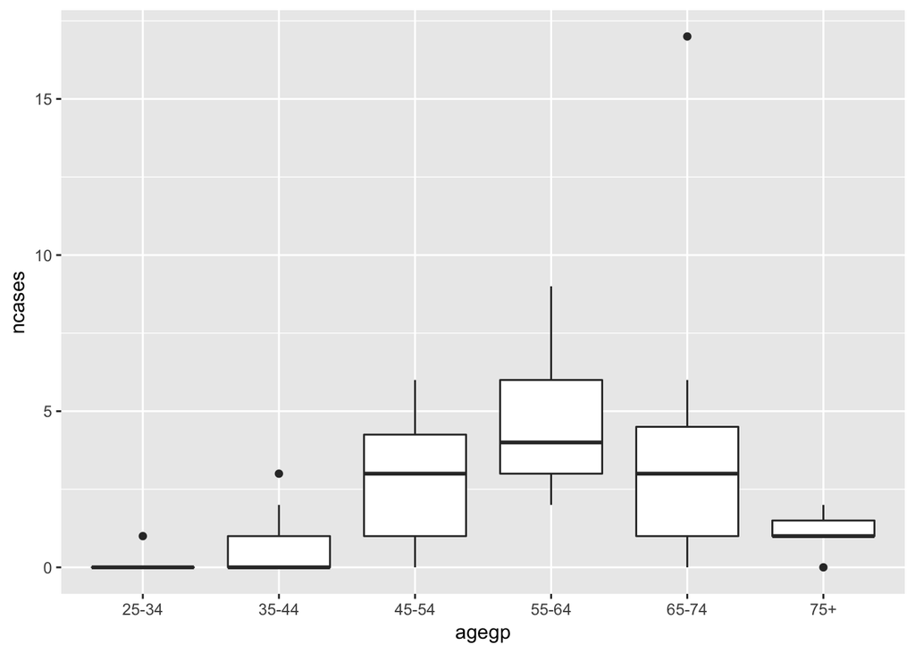

```r
ggplot(data = esoph, aes(x=agegp, y=ncases)) +
  geom_boxplot()
```

#### 三、請做出一個各年齡組的摘要表。 (30%)

- 這張摘要表應有6列，每列分別是一個年齡組 (10%)。
- 每列資料除了有年齡組(agegp)這個分組變項外，還需有sum_ncases變項， 代表在各年齡組中，所有ncases的總和 (10%)； 以及sum_ncontrols，代表在各年齡組中，所有ncontrols的總和 (10%)。

最後的結果會類似這樣：

```
  agegp sum_ncases sum_ncontrols
  <ord>      <dbl>         <dbl>
1 25-34
2 35-44
3 45-54          (values)
4 55-64
5 65-74
6   75+
```

```r
#library(dplyr)
esoph %>%
  group_by(agegp) %>%
  summarise(sum(ncases), sum(ncontrols))
```

```
## # A tibble: 6 x 3
##   agegp `sum(ncases)` `sum(ncontrols)`
##   <ord>         <dbl>            <dbl>
## 1 25-34             1              116
## 2 35-44             9              199
## 3 45-54            46              213
## 4 55-64            76              242
## 5 65-74            55              161
## 6   75+            13               44
```

#### 第四、不同酒精使用程度的摘要表。(30%)

- 假設現在僅關心是25-34和45-54兩個年齡組，他們在不同酒精使用程度中的個案數和控制組數。所以您僅需列出和25-34和45-54有關的資料(10%)。
- 這張表格應該有8列，並且共有4個變項：前兩個變項是年齡組與酒精使用程度。(10%) 後兩個變項是所有在該年齡組和酒精使用程度中，其個案數和控制組數的總和(10%)。

最後的結果會類似這樣：

```
  agegp     alcgp ncases ncontrols
  <ord>     <ord>  <dbl>     <dbl>
1 25-34 0-39g/day
2 25-34     40-79
3 25-34    80-119
4 25-34      120+     (values)
5 45-54 0-39g/day
6 45-54     40-79
7 45-54    80-119
8 45-54      120+
```

```r
#library(dplyr)

esoph %>%
  filter(agegp == "25-34" | agegp == "45-54") %>%
  group_by(agegp, alcgp) %>%
  summarise(ncases = sum(ncases),
            ncontrols = sum(ncontrols))
```

```
## # A tibble: 8 x 4
## # Groups:   agegp [?]
##   agegp     alcgp ncases ncontrols
##   <ord>     <ord>  <dbl>     <dbl>
## 1 25-34 0-39g/day      0        61
## 2 25-34     40-79      0        45
## 3 25-34    80-119      0         5
## 4 25-34      120+      1         5
## 5 45-54 0-39g/day      1        78
## 6 45-54     40-79     20        81
## 7 45-54    80-119     12        39
## 8 45-54      120+     13        15
```

## 進階選答題

[台北YouBike 開放資料](https://goo.gl/KLxuhf)是一個很常在資料科學專案應用或教學的例子。這個資料就在我們身邊，我們都接觸過他，甚至才剛剛貢獻過一點資料。這個作業請你試著接觸YouBike資料，看看裡面有什麼訊息。

### A. 把YouBike資料轉為data.frame (10%)

請你先到[台北YouBike 開放資料](https://goo.gl/KLxuhf)看一下資料描述。其中提到現在的介接網址是http://data.taipei/youbike。你可以直接在R裡面把這個檔案下載下來；或者手動把它下載下來後，把JSON格式換成R的data.frame。

提示：

- 轉資料格式、前處理，通常是資料科學裡最麻煩的事情。有時候運氣很好，一個彎轉對了全部風平浪靜； 但有時一個念頭轉錯了，資料會愈用愈亂。有幾個套件`rjson`、`jsonlite`、`tibble`和函數`do.call`, `rbind`, `as.numeric`可能是你會想要參考的。但依作法不同，不見得全部都用得上。
- 若您在這個步驟遇到問題，但仍想嘗試接下來的題目，您可以從[YouBike Demo Data](https://raw.githubusercontent.com/RLadsNTU/RLadsLab/master/W5_DataWrangling/youbike_demo_data.csv)開始。但依您的方法不同， 您可能還是需要有資料清理轉換的工作。
- 以下的code chunk會幫您載入Demo Data（但您還是需手動下載Demo Data檔案， 並放在和此檔案同一路徑下）。提醒您若使用Demo Data， 這一小題視為未作答。若您不需要以下這段程式碼，請直接刪除即可。
- 最後資料整理出來，應該會類似這樣（一些`_en`結尾的欄位可去除）：

  ```
  # A tibble: 378 x 11
   sno                       sna   tot   sbi  sarea                mday      lat      lng
     <int>                     <chr> <int> <int>  <chr>              <dttm>    <dbl>    <dbl>
   1     1     捷運市政府站(3號出口)   180   139 信義區 2017-10-09 03:19:35 25.04086 121.5679
   2     2 捷運國父紀念館站(2號出口)    48    31 大安區 2017-10-09 03:19:31 25.04125 121.5574
   3     3                台北市政府    40    13 信義區 2017-10-09 03:19:39 25.03780 121.5652
   4     4                  市民廣場    60    34 信義區 2017-10-09 03:19:40 25.03604 121.5623
   ...
  ```

```r
#library(readr)
demo_data_path <- "/Users/Thomas/Dropbox/Doctoraat/2017 Data Science R RLADS/Homework/youbike_demo_data.csv"
if(file.exists(demo_data_path)) {
    df.bike <- read_csv(demo_data_path,
                        locale=locale(encoding="UTF-8"))
} else {
    warning(paste0("Cannot find ", demo_data_path))
}
df.bike
```

```
## # A tibble: 378 x 11
##      sno                       sna   tot   sbi  sarea                mday
##    <int>                     <chr> <int> <int>  <chr>              <dttm>
##  1     1     捷運市政府站(3號出口)   180   139 信義區 2017-10-09 03:19:35
##  2     2 捷運國父紀念館站(2號出口)    48    31 大安區 2017-10-09 03:19:31
##  3     3                台北市政府    40    13 信義區 2017-10-09 03:19:39
##  4     4                  市民廣場    60    34 信義區 2017-10-09 03:19:40
##  5     5                  興雅國中    60    36 信義區 2017-10-09 03:19:39
##  6     6                  世貿二館    80     0 信義區 2017-09-08 00:43:45
##  7     7         信義廣場(台北101)    80    24 信義區 2017-10-09 03:19:39
##  8     8                  世貿三館    60    42 信義區 2017-10-09 03:19:22
##  9     9                    松德站    40    23 信義區 2017-10-09 03:19:19
## 10    10        台北市災害應變中心    54    30 信義區 2017-10-09 03:19:44
## # ... with 368 more rows, and 5 more variables: lat <dbl>, lng <dbl>,
## #   ar <chr>, bemp <int>, act <int>
```

```r
dim(df.bike)
```

```
## [1] 378  11
```

For explanation of the variables, see: Youbike VARIABLE INFORMATION

### B. 請按照台北各個行政區分組，計算每個行政區內，YouBike運作中站點的平均停車格數、目前車輛數、以及空位數。並且按照空位數（從小到大）排序。(5%)

### So, for every district, calculate the average of places, number of current bikes, number of open spots. Also arrange from small to big.

提示：

- 資料經過A的處理後，應該已經變成一個乾淨的data frame（或tibble），您在這步僅需把幾個變項選取出來，群組、平均、排序即可。記得YouBike資料裡有一欄是全站禁用狀態（act），我們只關心運作中的站點。

```r
df.bike %>%
  filter(act == 1) %>% #我們只關心運作中的站點。
  group_by(政區 = sarea) %>%
  summarise(平均停車 = mean(sbi),
            目前輛數 = sum(tot),
            空位數 = sum(bemp)) %>%
  arrange(空位數)
```

```
## # A tibble: 12 x 4
##      政區 平均停車 目前輛數 空位數
##     <chr>    <dbl>    <int>  <int>
##  1 大同區 17.42105      712    370
##  2 南港區 17.63636      806    411
##  3 文山區 16.70833      934    517
##  4 萬華區 12.63636      852    560
##  5 松山區 17.46667     1150    619
##  6 北投區 18.67857     1218    686
##  7 中正區 21.30303     1410    694
##  8 內湖區 18.97297     1412    694
##  9 士林區 15.78788     1302    765
## 10 信義區 23.73529     1614    791
## 11 中山區 19.86667     1822    908
## 12 大安區 17.55556     1938   1122
```

### C. 請篩選出空位率最高的5％站點，並且按照他們的空位率（從大到小）排序。(5%)

提示：

- 和上一題相似，但你需要自己計算一個新的欄位（空位率），並且要找出前5%的站點。選出前5%的資料至少有兩種可能的方法：（1）找出5%的空位率是多少，用該值去過濾資料；（2）先把資料按空位率排序之後，只取前5%的資料。兩個想法都是合理的，只是結果可能會些許不同。

```r
library(dplyr)

df.bike %>%
  filter(act == 1) %>% #我們只關心運作中的站點。
  select(sna, bemp, sbi, tot) %>%
  mutate(空位率 = bemp / tot * 100) %>%
  filter(空位率 >= 95) %>%
  arrange(desc(空位率)) %>%
  rename("站點" = sna,
         "空位" = bemp,
         "車輛" = sbi,
         "總停車格" = tot)
```

```
## # A tibble: 3 x 5
##           站點  空位  車輛 總停車格   空位率
##          <chr> <int> <int>    <int>    <dbl>
## 1 開封西寧路口    41     1       42 97.61905
## 2   大稻埕公園    37     1       38 97.36842
## 3 永吉松信路口    29     1       30 96.66667
```

### D. 請把站點的位置畫在一張地圖上，並且同時呈現每個站點的空位率。(5%)

### 提示：

- R畫圖的套件有很多，這一題只要您找到套件，剩下來就只是怎麼使用的問題。範例圖片用的是ggmap畫的，但類似功能的套件還有不少，如課堂上接觸過的leaflet，它是互動式的地圖，也是滿有趣的選擇。
- 為了統一作業結果，請如範例圖用點的顏色代表空位率，這在上述套件裡應該都可以做到，但方法可能會有些不同。
- 您可以參考這一張圖。您的空位率資料應該會不同，顏色、地圖樣式也可以自行選擇。

This is the preparatory code:

```r
df.map <- df.bike %>%
  filter(act == 1) %>% #我們只關心運作中的站點。
  mutate(vacancy = bemp / tot * 100) %>%
  select(station = sna,
         lat,
         long = lng,
         adress = ar,
         vacancy)

df.map
```

```
## # A tibble: 372 x 5
##                      station      lat     long
##                        <chr>    <dbl>    <dbl>
##  1     捷運市政府站(3號出口) 25.04086 121.5679
##  2 捷運國父紀念館站(2號出口) 25.04125 121.5574
##  3                台北市政府 25.03780 121.5652
##  4                  市民廣場 25.03604 121.5623
##  5                  興雅國中 25.03656 121.5687
##  6         信義廣場(台北101) 25.03304 121.5656
##  7                  世貿三館 25.03521 121.5637
##  8                    松德站 25.03159 121.5744
##  9        台北市災害應變中心 25.02866 121.5661
## 10                    三張犁 25.03494 121.5576
## # ... with 362 more rows, and 2 more variables: adress <chr>,
## #   vacancy <dbl>
```

This is my first map. It is a bit zoomed out so I can get all the stations.

[figure not shown]

```r
library(ggmap)
my_location <- c(lon=121.55, lat=25.05)

my_map <- get_map(location = my_location,
                 source ="google",
                 maptype = "roadmap",
                 zoom = 12)
bikemap1 <- ggmap(my_map) +
  geom_point(data = df.map,
             mapping = aes(x = long,
                           y = lat,
                           color = vacancy)) +
  ggtitle("Youbike data: 9 October 2017") +
  xlab("") +
  ylab("")

bikemap1
```

This is my second map. It is more zoomed in so I actually know where the stations are.

[figure not shown]

```r
library(ggmap)
my_location <- c(lon=121.55, lat=25.033333)

my_map <- get_map(location = my_location,
                 source ="google",
                 maptype = "roadmap",
                 zoom = 13)
bike_map2 <- ggmap(my_map) +
  geom_point(data = df.map,
             mapping = aes(x = long,
                           y = lat,
                           color = vacancy)) +
  ggtitle("Youbike data: 9 October 2017") +
  xlab("") +
  ylab("")

bike_map2
```